# Genomic-wide association study (GWAS)

Marcio Resende, Professor[^1]

Marco Antonio Peixoto, Post doc[^2]

Paul Adunola, PhD student[^3]

2023-10-11

## Part One: Introduction

This is an script developed using a population simulated in AlphaSimR package (Gaynor, Gorjanc, and Hickey 2021). One trait with high heritability and controlled by a few QTLs was simulated into two breeding populations. In addition, four GWAS models were implemented, as follows:

**Model 1.** Non Adjusted markers  
**Model 2.** Adjusted by Q  
**Model 3.** Adjusted by K  
**Model 4.** Adjusted by K+Q

## Loading the packages for the simulation/GWAS

```r
library(AlphaSimR) # For genomic simulation
library(rrBLUP) #For K and Q+K GWAS
library(qqman) #For Manhattan and Q-Q plots
library(ggfortify) #For plotting PCA
library(stringr) #For splitting strings
```

## Creating the population for the GWAS

### 1. Creating the base genome

```r
# Global parameters
#nQtlPerChr = 4 #Per pair of chromosome
#nSnpPerChr = 1000 # must be > nQtlPerChr

# Simulate mapping population
#set.seed(18556255)
#FOUNDERPOP = runMacs(nInd=200,
#                     nChr=10,
#                     segSites=nSnpPerChr,
#                     split=10)

# Simulate the trait of interest
#SP = SimParam$
#  new(FOUNDERPOP)$
#  restrSegSites(minSnpPerChr=nSnpPerChr,
#                minQtlPerChr=nSnpPerChr,
#                overlap=TRUE)$
#  addTraitA(nQtlPerChr,gamma=TRUE)$
#  addSnpChip(nSnpPerChr)$
#  setVarE(H2=0.8) # Trait heritability

#pop = newPop(FOUNDERPOP)
```

### 2. Creating a population structure

```r
#Create 2 sub populations
#popA = pop[1:100]
#popB = pop[101:200]

#Cycles of selection
#for(i in 1:4){
#  popA = selectCross(popA,
#                     nInd=10,
#                     nCrosses=20,
#                     nProgeny=5)
#  if(i<3){
#    popB = selectCross(popB,
#                       nInd=10,
#                       nCrosses=20,
#                       nProgeny=5)
#  }
#}

#Combining both pops
#pop = c(popA,popB)
```

## Organizing the data for the GWAS

For the GWAS analysis, we going to organize the data. We will need dosage matrix (coded -1,0,1), phenotypes values for the trait of interest, and the QTL positions.

```r
#rawGeno = pullSnpGeno(pop)
# Genotypes/SNP matrix/dosage matrix
#rawGeno = rawGeno-1
#geno = as.data.frame(t(rawGeno))
#geno = data.frame(snp=row.names(geno),
#                  chr=rep(1:10,each=nSnpPerChr),
#                  pos=rep(1:nSnpPerChr,10),
#                  geno)

# Create "pheno" data.frames for rrBLUP
#pheno = data.frame(gid=names(geno)[-(1:3)],
#                   trait1=pop@pheno[,1])

# Tracking the information of population
#phenoQ = data.frame(gid=pheno$gid,
#                    subPop=factor(rep(c("a","b"),each=100)),
#                    trait1=pheno$trait1)

# Find QTL locations within SNP chip and chromosome position
#qtl =  paste0(rep(1:10, each = 4), '_',SP$traits[[1]]@lociLoc)

#df = data.frame(eff = SP$traits[[1]]@addEff,
#                Mkr = SP$traits[[1]]@lociLoc,
#                qtl = qtl)

#write.csv(geno,file = "genofile.csv",row.names = F)
#write.csv(phenoQ, file = "phenofile.csv", row.names = F)
#write.csv(df, file = "qtl_pos.csv", row.names = F)
```

### 3. Import data

```r
X.org = read.csv("genofile.csv") #SNP data
#X.org[1:5,1:5]
X = t(X.org[,-c(1:3)]) #Transpose marker
X = as.matrix(X) #transforming to matrix
colnames(X) = X.org$snp
X[1:5,1:5]
```

```
##      1_1 1_2 1_3 1_4 1_5
## X701  -1   1   1  -1   1
## X702  -1   1   1  -1   1
## X703  -1   1   1  -1   1
## X704  -1   1   1  -1   1
## X705  -1   1   1  -1   1
```

```r
dat = read.csv("phenofile.csv") #Phenotypic data
str(dat)
```

```
## 'data.frame':    200 obs. of  3 variables:
##  $ gid   : chr  "X701" "X702" "X703" "X704" ...
##  $ subPop: chr  "a" "a" "a" "a" ...
##  $ trait1: num  2.99 4.13 4.34 3.67 4.55 ...
```

```r
unique(dat$subPop)
```

```
## [1] "a" "b"
```

```r
snp_qtl = read.csv("qtl_pos.csv") #Marker effect from simulation
```

### 4. PCA and population genotypes

In this step we will extract the SNPs from the core population and we will create a PCA to explore the structure in the data.

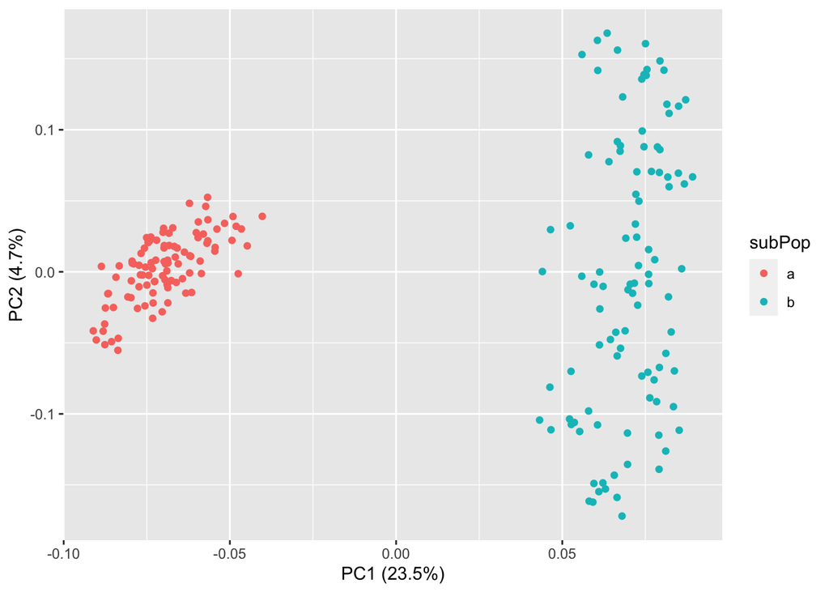

```r
# Format genotypes for rrBLUP
X2 = X+1
freq = colMeans(X2)/2
MAF = apply(cbind(freq,1-freq),1,min)

# Ploting PCA
pca_res <- prcomp(X)

autoplot(pca_res,data=dat,colour="subPop")
```

### 5. Fit GWAS Models

For the GWAS analysis, we going to organize the data. We will need dosage matrix (coded -1,0,1), phenotypes values for the trait of interest, and the QTL positions.

```r
geno = X.org
```

## Model 1 - GWAS with no adjustament

Single marker regression

$$y = S\alpha + e$$

```r
#No adjustments----
model0 = data.frame(snp=geno$snp,
                    chr=geno$chr,
                    pos=geno$pos,
                    trait1=rep(NA,nrow(dat)))
model0$chr=as.numeric(model0$chr);model0$pos=as.numeric(model0$pos)

for(i in 1:ncol(X)){
  if(MAF[i]>=0.05){
    #Fit linear model with lm() and extract p-value
    mod1 = summary(lm(dat$trait1~X[,i]))
    tmp = mod1[[4]][2,4]
    #Check for markers confounded with structure
    if(is.na(tmp)){
      model0$trait1[i] = 1
    }else{
      model0$trait1[i] = tmp
    }
  }else{
    model0$trait1[i] = 1
  }
}

#Account for p-value=0
model0$trait1[model0$trait1==0] = 1e-300
```

## Model 2 - GWAS correcting with population structure (Q)

Single marker regression with population as fixed effect

$$y = X\beta + S\alpha + e$$

```r
#Adjust for population structure (Q)----
modelQ = model0
modelQ$chr=as.numeric(modelQ$chr);modelQ$pos=as.numeric(modelQ$pos)

for(i in 1:ncol(X)){
  if(MAF[i]>=0.05){
    #Fit linear model with lm() and extract p-value
    mod2 = summary(lm(dat$trait1~dat$subPop+X[,i]))[[4]]
    if(dim(mod2)[1] == 2){
      tmp = NA
    }else{
      tmp = mod2[3,4]
    }
    #Check for markers confounded with structure
    if(is.na(tmp)){
      modelQ$trait1[i] = 1
    }else{
      modelQ$trait1[i] = tmp
    }
  }else{
    modelQ$trait1[i] = 1
  }
}
#Account for p-value=0
modelQ$trait1[modelQ$trait1==0] = 1e-300
```

## Model 3 - GWAS correcting with Kinship matrix (K)

Single marker regression with covariance information among the individuals. The matrix will be calculated internally by the function ’A.mat`.

$$y = S\alpha + Qv + e$$

```r
#Adjust for kinship (K)----
Kmat = A.mat(X)
modelK = GWAS(pheno=dat[,-2],geno=geno,K=Kmat,plot=FALSE)
```

```
## [1] "GWAS for trait: trait1"
## [1] "Variance components estimated. Testing markers."
```

```r
modelK$trait1 = 10^(-modelK$trait1) #Revert to p-value
```

## Model 4 - GWAS correcting with both, Q and K

$$y = X\beta + S\alpha + Qv + e$$

```r
#Adjust for both structure and kinship (Q+K)----
modelQK = GWAS(pheno=dat,geno=geno,K=Kmat,fixed="subPop",plot=FALSE)
```

```
## [1] "GWAS for trait: trait1"
## [1] "Variance components estimated. Testing markers."
```

```r
modelQK$trait1 = 10^(-modelQK$trait1) #Revert to p-value
```

### 6. Manhattan plot

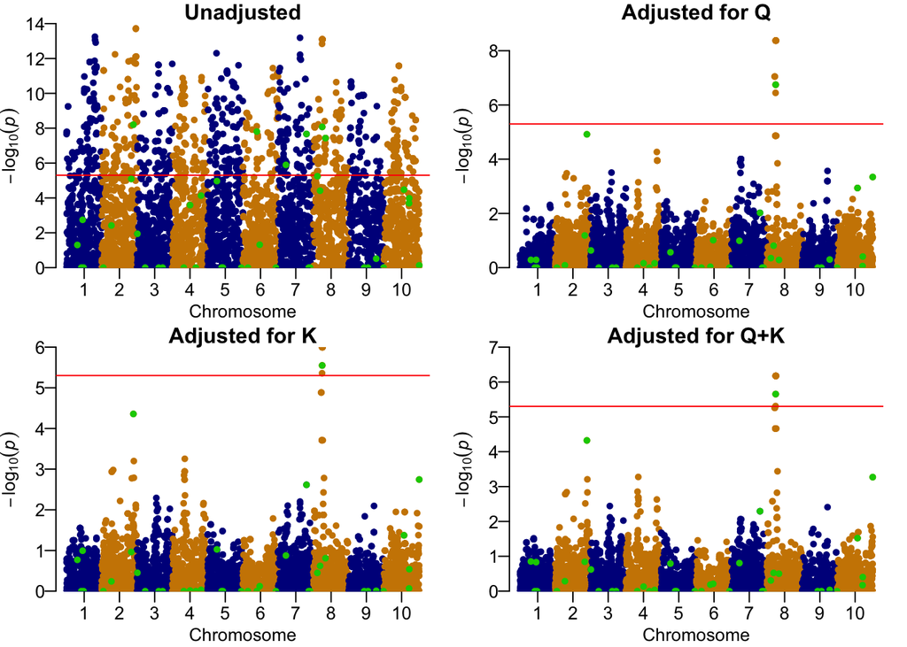

```r
# Assuming Bonferroni Threshold (0.05/m)
hline = -log10(0.05/ncol(X))

# Manhattan plots
op = par(mfrow=c(2,2),mai=c(.9,.9,0.9,0.9),
         mar=c(2.5,2.5,1,1)+0.1,
         mgp = c(1.5,0.5,0))

manhattan(model0,chr="chr",bp="pos",p="trait1",snp="snp",highlight=snp_qtl$qtl,
         main="Unadjusted", col = c("blue4", "orange3"),
          suggestiveline = FALSE, genomewideline = hline)

manhattan(modelQ,chr="chr",bp="pos",p="trait1",snp="snp",highlight=snp_qtl$qtl,
          main="Adjusted for Q", col = c("blue4", "orange3"),
          suggestiveline = FALSE, genomewideline = hline)

manhattan(modelK,chr="chr",bp="pos",p="trait1",snp="snp",highlight=snp_qtl$qtl,
          main="Adjusted for K", col = c("blue4", "orange3"),
          suggestiveline = FALSE, genomewideline = hline)

manhattan(modelQK,chr="chr",bp="pos",p="trait1",snp="snp",highlight=snp_qtl$qtl,
          main="Adjusted for Q+K", col = c("blue4", "orange3"),
          suggestiveline = FALSE, genomewideline = hline)
```

### 7. QQ-plot

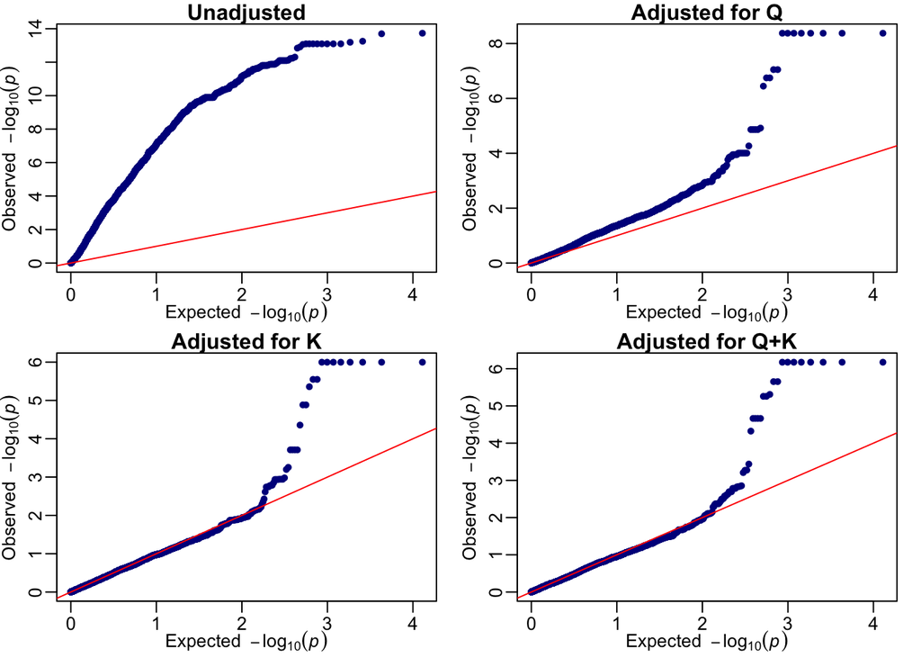

```r
#Q-Q plots
op = par(mfrow=c(2,2),mai=c(.9,.9,0.9,0.9),
         mar=c(2.5,2.5,1,1)+0.1,
         mgp = c(1.5,0.5,0))
qq(model0$trait1,main="Unadjusted", col = "blue4")
qq(modelQ$trait1,main="Adjusted for Q", col = "blue4")
qq(modelK$trait1,main="Adjusted for K", col = "blue4")
qq(modelQK$trait1,main="Adjusted for Q+K", col = "blue4")
```